# 02-exercises

Christopher Brown

April 13, 2016

This exercise uses the **Fuel Economy** data set from the **AppliedPredicitiveModeling** package.

## Exercise 1

Hint: See `?cars2010`

- After the **Fuel Economy** data is loaded, combine three data sets into one data set. (Note: The name `dat` is very often used in these situations, `data` is a reserved R word.)

```r
dat <- rbind(cars2010, cars2011, cars2012)    # Define
```

- What is a good “naive guess” of FE? Show your work

```r
naive_guess <- mean(dat$FE)
```

- plot FE (Fuel Econonomy) vs. EngDisp. Plot the naive guess.

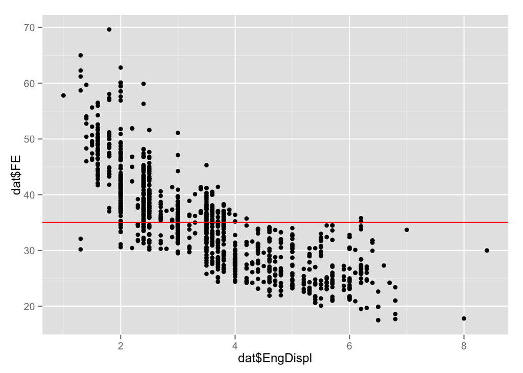

```r
qplot( y=dat$FE, x=dat$EngDispl ) + geom_hline(yintercept=naive_guess, color="red")
```

- Sample 10 observations from `dat`
- Plot this data. Add a line for the naive_guess.

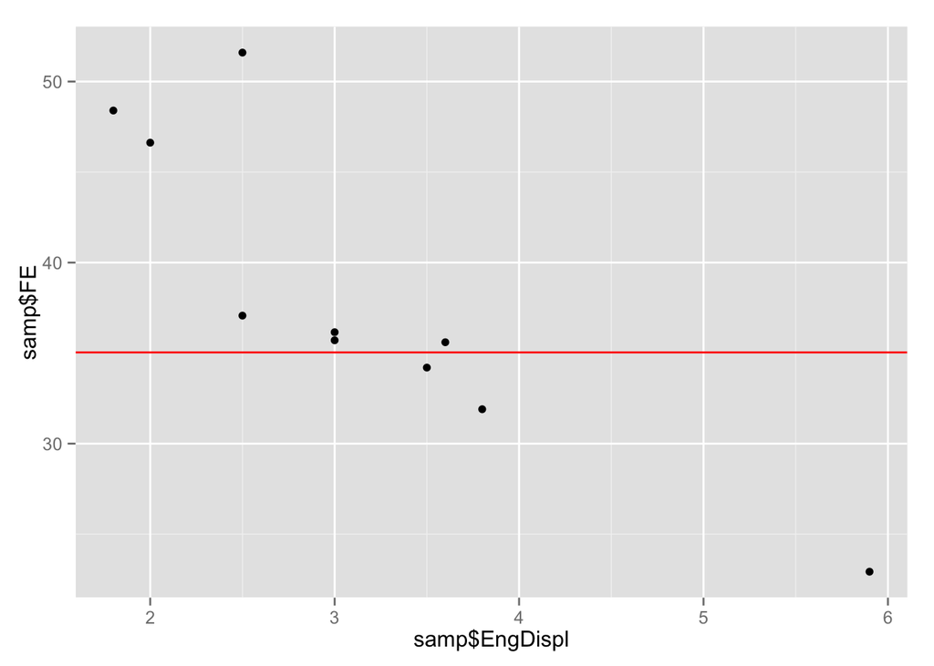

```r
set.seed(314)

# Sample
samp <- dat %>% sample_n(10)
# to explicitly specify function package also can:
# dplyr::sample_n

# Plots
qplot(y = samp$FE, x = samp$EngDispl) + geom_hline(yintercept = naive_guess, color = 'red')
```

## Exercise 2:

Write a loss functions for calculating: - Root Mean Square Error - Mean Absolute Error - Median Absolute Error

```r
rmse <- function(y,yhat) {
return ((y - yhat)^2 %>% mean %>% sqrt)
}

mae <- function(y, yhat) {
return ((y - yhat) %>% abs %>% mean)
}

medae <- function(y, yhat) {
return ((y - yhat) %>% median)
}
```

Use these functions to evaluate the loss/performance of: - the naive guess

```r
y <- samp$FE
yhat <- naive_guess
paste('RMSE naive:', format(round(rmse(y,yhat), 2), nsmall = 2))
```

```
## [1] "RMSE naive: 8.66"
```

```r
paste('MAE naive:', format(round(mae(y,yhat), 2), nsmall = 2))
```

```
## [1] "MAE naive: 6.20"
```

```r
paste('MEDAE naive:', format(round(medae(y,yhat), 2), nsmall = 2))
```

```
## [1] "MEDAE naive: 0.89"
```

## Exercise 3: Linear Model and Model Performance

- Use `lm` to create a linear model fitting the relationship between FE and EngDispl for the cars2010 data set

```r
fit.2010 <- lm(FE ~ EngDispl, data = cars2010)
```

- Use your functions to evaluate the training error
- Use your model to: – predict the FE for 2011. What is the RMSE errors associated with the predictions. – predict the FE for 2012. What is the RMSE errors associated with the predictions.

```r
y.2010 <- predict(fit.2010, newdata=cars2010)
y.2011 <- fit.2010 %>% predict(cars2011)
# newdata=, not data = , otherwise creates preds for 2010 still:
y.2011 <- predict(fit.2010, newdata=cars2011)
y.2012 <- fit.2010 %>% predict(cars2012)

rmse.2010 <- rmse(cars2010$FE, y.2010)
rmse.2011 <- rmse(cars2011$FE, y.2011)
rmse.2012 <- rmse(cars2012$FE, y.2012)
```

```r
# DO NOT EDIT
rmse.2010
```

```
## [1] 4.62
```

```r
rmse.2011
```

```
## [1] 5.163
```

```r
rmse.2012
```

```
## [1] 6.639
```

## Exercise 4:

- Model the fuel economy (`FE`) as a function of `EngDispl`, `NumCyl` and `VarValve` using the `cars2011` data set.
- Provide betas

```r
fit.multivar <- lm(FE ~ EngDispl + NumCyl + VarValveLift, data = cars2011)
summary(fit.multivar)
```

```
##
## Call:
## lm(formula = FE ~ EngDispl + NumCyl + VarValveLift, data = cars2011)
##
## Residuals:
##     Min      1Q  Median      3Q     Max
## -12.256  -3.217  -0.954   2.706  17.983
##
## Coefficients:
##              Estimate Std. Error t value Pr(>|t|)
## (Intercept)    55.901      1.275   43.85  < 2e-16 ***
## EngDispl       -3.942      0.543   -7.26  5.2e-12 ***
## NumCyl         -1.131      0.441   -2.57    0.011 *
## VarValveLift    0.584      0.851    0.69    0.493
## ---
## Signif. codes:  0 '***' 0.001 '**' 0.01 '*' 0.05 '.' 0.1 ' ' 1
##
## Residual standard error: 4.99 on 241 degrees of freedom
## Multiple R-squared:  0.71,   Adjusted R-squared:  0.707
## F-statistic:  197 on 3 and 241 DF,  p-value: <2e-16
```

```r
# kill VarValveLift - insignificant predictor. replace with VarValveTiming:
fit.multivar <- lm(FE ~ EngDispl + NumCyl + VarValveTiming, data = cars2011)
summary(fit.multivar)
```

```
##
## Call:
## lm(formula = FE ~ EngDispl + NumCyl + VarValveTiming, data = cars2011)
##
## Residuals:
##    Min     1Q Median     3Q    Max
## -10.69  -2.77  -0.96   2.28  19.12
##
## Coefficients:
##                Estimate Std. Error t value Pr(>|t|)
## (Intercept)      52.664      1.470   35.82  < 2e-16 ***
## EngDispl         -3.906      0.525   -7.45  1.7e-12 ***
## NumCyl           -1.110      0.427   -2.60   0.0099 **
## VarValveTiming    3.594      0.886    4.06  6.8e-05 ***
## ---
## Signif. codes:  0 '***' 0.001 '**' 0.01 '*' 0.05 '.' 0.1 ' ' 1
##
## Residual standard error: 4.83 on 241 degrees of freedom
## Multiple R-squared:  0.728,  Adjusted R-squared:  0.725
## F-statistic:  215 on 3 and 241 DF,  p-value: <2e-16
```

```r
betas <- fit.multivar$coefficients
print(betas)
```

```
##    (Intercept)       EngDispl         NumCyl VarValveTiming
##         52.664         -3.906         -1.110          3.594
```